[figure not shown]

24 October 2024

# What do we need to know today to create a baseline AI model?

## Scenario / AI use case

- A colleague would like to understand if AI could be used to automatically diagnose breast cancer (malignant) and not breast cancer (benign) from images of fine needle aspirates (FNAs) of breast masses.
- They have already found some data they they would like you to work with.
- They would like to use this AI tool at their own health centre to support clinicians to diagnore breast cancer.

## Skilled team

- Everyone on the call
- Can be made up of subject matter experts e.g. clinicians; data engineers; data scientists; AI specialists; machine learning engineers; business analysts; project managers, and users e.g. patients

## Programming languages, software and hardware

- Python using [Kaggle Notebooks](https://www.kaggle.com/code) and using Kaggle Notebooks hardware

## Data

- Publicly avaliable data from Wolberg, William, et al. "Breast Cancer Wisconsin (Diagnostic)." UCI Machine Learning Repository, 1993, https://doi.org/10.24432/C5DW2B.
- More information below.

## AI algorithms

- Linear Support Vector Classifier.
- More information below.

## AI model steps

1) Agree full project with clients/customers/users, including scope, timeframe and specific plan. Keep customers continually updated throughout the next steps. 2) Develop the model. 3) Evaluate the model. 4) Explain the model. 5) Improve the model until everyone is happy to use the model in live systems.

# 1. Agree full project with clients/customers/users, including scope, timeframe and specific plan.

## 1.1. Data

- We have agreed to use publicly avaliable data from Wolberg, William, et al. "Breast Cancer Wisconsin (Diagnostic)." UCI Machine Learning Repository, 1993, https://doi.org/10.24432/C5DW2B. The original research paper can be seen here https://minds.wisconsin.edu/bitstream/handle/1793/59692/TR1131.pdf
- 569 fine needle aspirations (FNAs) were taken. For each FNA, the aspirated material was expressed onto a glass slide and stained. A physician then decided what part of the glass slide was digitised as an image.
- Each image was then annotated with approximate initial boundaries of enough nuclei to provide a respesentative sample.
- Then their system smoothed out the nuclei boundaries and summarised all of the nuclei with 30 features such as mean radius, mean perimeter and mean area.
- From the way the research paper is worded, it is assumed that each FNA is from a different person, however, this is not explicity said.

[figure not shown]

Source: https://my.clevelandclinic.org/health/diagnostics/17872-fine-needle-aspiration-fna

[figure not shown]

Source: https://doi.org/10.24432/C5DW2B

[figure not shown]

Source: https://doi.org/10.24432/C5DW2B

### 1.1.1. Features

> Features are the values that a supervised model uses to predict the label...

> In a weather model that predicts rainfall, the features could be latitude, longitude, temperature, humidity, cloud coverage, wind direction, and atmospheric pressure.

Source: https://developers.google.com/machine-learning/intro-to-ml/supervised

- The 30 features we are using represents a summary of the nuclei boundaries on each image such as mean radius, mean perimeter and mean area.

For example:

[figure not shown]

### 1.1.2. Targets or labels

- Targets or labels are "the 'answer,' or the value we want the model to predict."
- "In a weather model that predicts rainfall,... the label would be rainfall amount." Or could be Yes/No for email spam detection, or 0/1. Source: https://developers.google.com/machine-learning/intro-to-ml/supervised
- The targets we are using are 0 and 1 which represents whether the tumour associated with the image is cancerous (=0) or non-cancerous (=1).

For example:

[figure not shown]

### 1.1.3. Is the data suitable for this task?

Normally, this would be agreed by the whole project team.

- What does a row of data represent? Is each row a different person? Is each row a different image or just a different shape within an image?
- How was the data collected? Was the same device used? Is there any bias in how the data was collected? Will the model likely work well on other data?
- Who cleaned the data? Has this been validated?/Is it correct?
- Who did the labelling? Was this validated?
- Is the data representative of who this AI tool will be used on? Will the tool work for everyone or are there groups of people where the tool performs worse?
- Ultimately, we want the model which uses the data to be valid, reliable and generalisable. For more information, see https://www.healthknowledge.org.uk/content/validity-reliability-and-generalisability

### 1.1.4. Exploratory Data Analysis (EDA)

> The main purpose of EDA is to help look at data before making any assumptions. It can help identify obvious errors, as well as better understand patterns within the data, detect outliers or anomalous events, find interesting relations among the variables...

> EDA also helps stakeholders by confirming they are asking the right questions...

> Once EDA is complete and insights are drawn, its features can then be used for more sophisticated data analysis or modeling.

Source: https://www.ibm.com/topics/exploratory-data-analysis

- By doing EDA at this stage, it may be found that the data is not suitable for the required task.
- As this notbook is focused on model creation, full EDA has not been done.
- By continuing, it is assumed that full EDA was completed and provided sufficient results to continue to build the model.
- An example of part of EDA will be shown below after we have loaded the data in.

## 1.2. Agreed to do

### 1.2.1. Baseline AI model

“Baseline models are basic models that are used as a foundation for more complicated models. They are a benchmark against which more complex models may be evaluated.”

Source: https://www.deepchecks.com/glossary/baseline-models/

- Let's assume there aren't any models that use this data for this task.

### 1.2.2. Model creation plan:

- a) Train and test split
- b) Feature scaling on train data only
- c) Train model using chosen algorithm and train data only
- d) Evaluate the model using test data
- e) Explain the model

## 1.3. Agreed to explore at a later stage

### 1.3.1. Feature selection and extraction

We will be using all of the features in this model.

- Feature engineering

> ... feature engineering is a crucial preprocessing technique that requires selecting the most relevant aspects of raw training data for both the predictive task and model type under consideration.

Source: https://www.ibm.com/topics/feature-engineering

> Feature engineering is the process of transforming raw data into features that are suitable for machine learning models.

Source: https://www.geeksforgeeks.org/what-is-feature-engineering/

We don't need to do feature engineering as it has already been done on the dataset, summarising the image data into features, for example, mean area.

- Feature selection

> Feature selection is a process of selecting a subset of relevant features from the original set of features. The goal is to reduce the dimensionality of the feature space, simplify the model, and improve its generalization performance.
- Feature extraction

> Feature extraction is a process of transforming the original features into a new set of features that are more informative and compact. The goal is to capture the essential information from the original features and represent it in a lower-dimensional feature space.

Source: https://www.geeksforgeeks.org/difference-between-feature-selection-and-feature-extraction/

### 1.3.2. Hyperparameter tuning

We will use default hyperparameters in this model.

> When you’re training machine learning models, each dataset and model needs a different set of hyperparameters, which are a kind of variable. The only way to determine these is through multiple experiments, where you pick a set of hyperparameters and run them through your model. This is called hyperparameter tuning. In essence, you're training your model sequentially with different sets of hyperparameters. This process can be manual, or you can pick one of several automated hyperparameter tuning methods.

Source: https://aws.amazon.com/what-is/hyperparameter-tuning/

# 2. Develop the model

## 2.1. Import chosen libraries

- To learn more about sklearn, search the package names on their official website https://scikit-learn.org/stable/index.html
- To learn more about pandas, search their official website https://pandas.pydata.org/docs/
- To learn more about matplotlib, search their official website https://matplotlib.org/stable/search.html

```python
#to manipulate data tables
import pandas as pd

#to load the breast cancer data
from sklearn.datasets import load_breast_cancer

#to perform splitting the data into a train set and test set
from sklearn.model_selection import train_test_split

#to perform feature scaling
from sklearn.preprocessing import RobustScaler

#to perform linear support vector classification
from sklearn.svm import LinearSVC

#to show graphs of the data
import matplotlib.pyplot as plt

# to show a chart of the confusion matrix
from sklearn.metrics import ConfusionMatrixDisplay
```

## 2.2. Set the seed state, or `random_state`

> Pseudo Random Number Generator(PRNG) refers to an algorithm that uses mathematical formulas to produce sequences of random numbers...

> A PRNG starts from an arbitrary starting state using a seed state.

> Many numbers are generated in a short time and can also be reproduced later, if the starting point in the sequence is known. Hence, the numbers are deterministic and efficient.

Source: https://www.geeksforgeeks.org/pseudo-random-number-generator-prng/

> Setting a `random_state` ensures that the results are reproducible.

Source: https://www.geeksforgeeks.org/what-is-scikit-learn-random-state-in-splitting-dataset/

```python
chosen_random_state = 2541
```

## 2.3. Load the data

The data can be loaded from the Python library sklearn.

- `return_X_y=True` just returns the image data and the cancer classification of malignant (represented as 0) or benign (represented as 1)
- `as_frame=True` returns both datasets as a pandas DataFrame and Series

Source: https://scikit-learn.org/stable/modules/generated/sklearn.datasets.load_breast_cancer.html

```python
data = load_breast_cancer(return_X_y=True, as_frame=True)
```

```python
print(f"data has {type(data)} and there are {len(data)} items")
```

```
data has <class 'tuple'> and there are 2 items
```

```python
#the first item, which has index 0 is the image data
x = data[0]

#the second item, which has index 1 is the cancer classification
y = data[1]
```

```python
#this is the three rows of x, the image data
x.head(3)
```

|  | mean radius | mean texture | mean perimeter | mean area | mean smoothness | mean compactness | mean concavity | mean concave points | mean symmetry | mean fractal dimension | ... | worst radius | worst texture | worst perimeter | worst area | worst smoothness | worst compactness | worst concavity | worst concave points | worst symmetry | worst fractal dimension |
| --- | --- | --- | --- | --- | --- | --- | --- | --- | --- | --- | --- | --- | --- | --- | --- | --- | --- | --- | --- | --- | --- |
| 0 | 17.99 | 10.38 | 122.8 | 1001.0 | 0.11840 | 0.27760 | 0.3001 | 0.14710 | 0.2419 | 0.07871 | ... | 25.38 | 17.33 | 184.6 | 2019.0 | 0.1622 | 0.6656 | 0.7119 | 0.2654 | 0.4601 | 0.11890 |
| 1 | 20.57 | 17.77 | 132.9 | 1326.0 | 0.08474 | 0.07864 | 0.0869 | 0.07017 | 0.1812 | 0.05667 | ... | 24.99 | 23.41 | 158.8 | 1956.0 | 0.1238 | 0.1866 | 0.2416 | 0.1860 | 0.2750 | 0.08902 |
| 2 | 19.69 | 21.25 | 130.0 | 1203.0 | 0.10960 | 0.15990 | 0.1974 | 0.12790 | 0.2069 | 0.05999 | ... | 23.57 | 25.53 | 152.5 | 1709.0 | 0.1444 | 0.4245 | 0.4504 | 0.2430 | 0.3613 | 0.08758 |

3 rows × 30 columns

```python
#this is the three rows of y, the cancer classification
y.head(3)
```

```
0    0
1    0
2    0
Name: target, dtype: int64
```

```python
#there are 357 benign cases (represented as 1) and 212 malignant cases (represented as 0)
y.value_counts()
```

```
target
1    357
0    212
Name: count, dtype: int64
```

### 2.3.1. Exploratory data analysis (EDA) that should have been done during stage 1

Exploratory Data Analysis (EDA) includes understanding what the data looks like and this would have been done during stage 1 when the full project was agreed with customers. See section 1.1.4.

This will be done now as we had not loaded the data in section 1.1.4.

We will not do full EDA here and will only look at the shape of the data using box plots and histograms to support our decisions for feature scaling.

The first chart shows a box plot for each feature. Information on how to read a box plot can be found through the link https://www.codementor.io/@mgalarny/understanding-boxplots-10cbs1cyap

You can see that some of the features are much bigger than others. For example, "worst area" and "mean area" are much larger than other features.

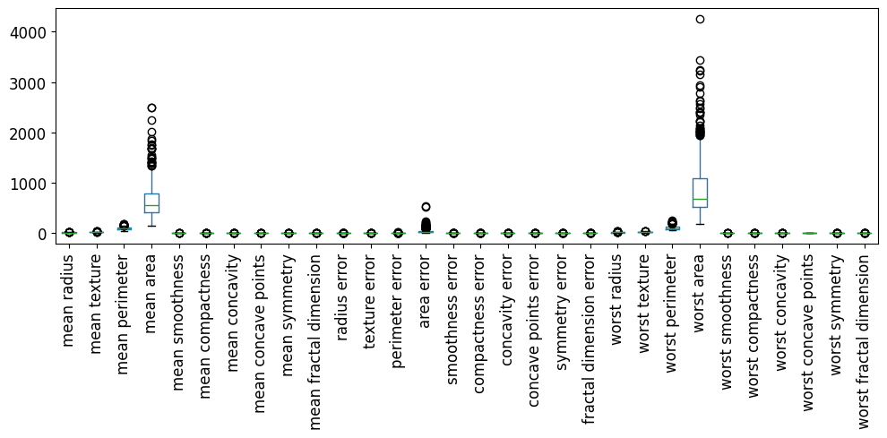

```python
boxplots = x.boxplot( # x is the data about the features and we are creating a boxplot for each feature
                     figsize= (10, 5), # this sets the (width, height) of the chart in inches so 10 inches by 5 inches
                     grid=False, # this removes the gridlines. Try setting this to True and rerunning it to see the gridlines
                     rot=90, # this rotates the x axis labels by 90 degrees so you can read them
                     fontsize=12 # this changes the font size to size 12
                     );

plt.tight_layout() # Adjust the padding between and around subplots by default value of 1.08. The padding is equal to 1.08 multiplied by the font size.
plt.show() # this forces the last plot to show. Useful if you have multiple plots in one code cell.
```

The second chart shows a histogram for each feature with their own x and y axes.

You can see that some features look normally distributed (bell curve or looks like a mountain with a peak) and some look like other distributions. See this link for some examples of distributions https://www.itl.nist.gov/div898/handbook/eda/section3/eda366.htm

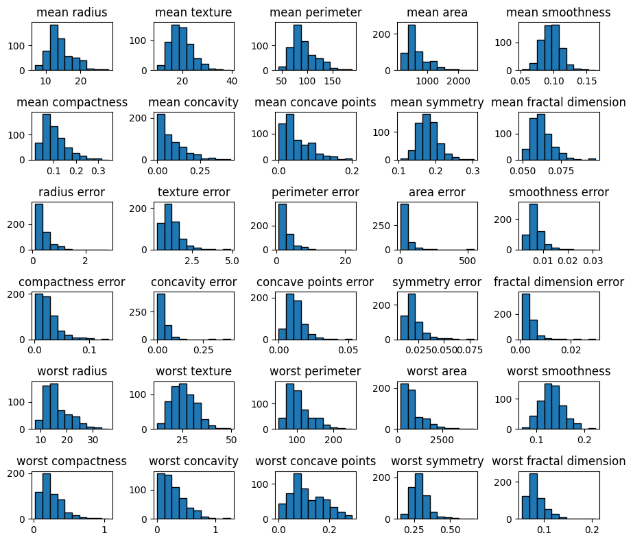

```python
histograms = x.hist(# x is the data about the features and we are creating a histogram for each feature
                    figsize=(9,8), # this sets the (width, height) of the chart in inches so 8 inches by 8 inches
                    grid=False, # this removes the gridlines. Try setting this to True and rerunning it to see the gridlines
                    sharex=False, # this forces each of the histograms to be drawn WITHOUT the same x axis
                    ec="k" # ec stands for edge colour, the outline of the bars. "k" is the colour black.
                    );

plt.tight_layout() # Adjust the padding between and around subplots by default value of 1.08. The padding is equal to 1.08 multiplied by the font size.
plt.show() # this forces the last plot to show. Useful if you have multiple plots in one code cell.
```

## 2.4. Train/test split

> Data splitting is a commonly used approach for model validation, where we split a given dataset into two disjoint sets: training and testing. The statistical and machine learning models are then fitted on the training set and validated using the testing set. By holding out a set of data for validation separate from training, we can evaluate and compare the predictive performance of different models without worrying about possible overfitting on the training set.

> ...

> The foregoing data splitting methods can be implemented once we specify a splitting ratio. A commonly used ratio is 80:20, which means 80% of the data is for training and 20% for testing. Other ratios such as 70:30, 60:40, and even 50:50 are also used in practice. There does not seem to be clear guidance on what ratio is best or optimal for a given dataset. The 80:20 split draws its justification from the well-known Pareto principle, but that is again just a thumb rule used by practitioners.

Source: https://onlinelibrary.wiley.com/doi/10.1002/sam.11583

For example, we could split a dataset into train and test based on time period. In this example, it is currently 2016. We use data from 2011 to 2015 to train the model and withold data from 2015 to 2016. We are pretending that the model was created in 2015 so that we know for sure what happens in the future, which is our test set.

[figure not shown]

There are different methods to split the data, depending on the data being used and the problem but for simplicity for this short session, we will use the sklearn defaults.

```python
x_train, x_test, y_train, y_test = train_test_split( # this function splits x and y data into 4 parts. The first two are where the features, or x, are split into train and test. The second two are where the targets, or y, are split into train and test.
                                                    x, # this is the features data
                                                    y, # this is the target data
                                                    test_size=0.2, # this is the percentage of data that will be sectioned off in the test set so the train set will have 80% of the data and the test set will have 20%
                                                    random_state=chosen_random_state # this is the seed state or random state, see section 2.2. for more information
                                                    )
```

```python
print(f"""x shape is {x.shape} which is (number of rows, columns)
y shape is {y.shape}. Where there is no value, this represents 1. For example, y has 1 column

x_train shape is {x_train.shape} which is (number of rows, columns). {len(x_train)} is 80% of the data.
y_train shape is {y_train.shape}. Where there is no value, this represents 1. For example, y has 1 column

x_test shape is {x_test.shape}. {len(x_test)} is 20% of the data.
y_test shape is {y_test.shape}. Where there is no value, this represents 1. For example, y has 1 column""")
```

```
x shape is (569, 30) which is (number of rows, columns)
y shape is (569,). Where there is no value, this represents 1. For example, y has 1 column

x_train shape is (455, 30) which is (number of rows, columns). 455 is 80% of the data.
y_train shape is (455,). Where there is no value, this represents 1. For example, y has 1 column

x_test shape is (114, 30). 114 is 20% of the data.
y_test shape is (114,). Where there is no value, this represents 1. For example, y has 1 column
```

## 2.5. Feature scaling

As seen in section 2.3.1, our features have different minimums and maximums and some features have much larger values than other features.

> Feature Scaling is a technique to standardize the independent features present in the data in a fixed range. It is performed during the data pre-processing to handle highly varying magnitudes or values or units. If feature scaling is not done, then a machine learning algorithm tends to weigh greater values, higher and consider smaller values as the lower values, regardless of the unit of the values.

Feature scaling is beneficial because:

> - Scaling guarantees that all features are on a comparable scale and have comparable ranges...
> - Algorithm performance improvement: When the features are scaled, several machine learning methods... perform b|etter or converge more quickly...
> - Preventing numerical instability:... having features with radically differing scales can result in numerical overflow or underflow problems..
> - Scaling features makes ensuring that each characteristic is given the same consideration during the learning process. Without scaling, bigger scale features could dominate the learning, producing skewed outcomes. This bias is removed through scaling, which also guarantees that each feature contributes fairly to model predictions.

Source: https://www.geeksforgeeks.org/ml-feature-scaling-part-2/

There are multiple methods to scale features such as StandardScaler (z-score normalisation), MinMaxScaler and RobustScaler. Theoretically, the most appropriate method will depend on the distribution or shape of the data and whether there are outliers.

However,

> In practice we often ignore the shape of the distribution and just transform the data to center it by removing the mean value of each feature, then scale it by dividing non-constant features by their standard deviation.

More information can be found through the link https://scikit-learn.org/1.5/modules/preprocessing.html

We will use the RobustScaler in this instance as the method is less sensitive to outliers than MinMaxScaler.

> This Scaler removes the median and scales the data according to the quantile range (defaults to IQR: Interquartile Range). The IQR is the range between the 1st quartile (25th quantile) and the 3rd quartile (75th quantile).

Source: https://scikit-learn.org/dev/modules/generated/sklearn.preprocessing.RobustScaler.html

$$ x_{robust scaled} = \frac{x_{old} - median}{\text{75th percentile} - \text{25th percentile}}\ $$$$ \text{interquartile range} = \text{75th percentile} - \text{25th percentile} $$

```python
# use the x_train data to create the formula to scale x
robust_scaler = RobustScaler().fit(x_train)

# this prints out the medians and the interquartile ranges for the respective columns
print(f"""columns:
{robust_scaler.feature_names_in_.astype(str)}

medians:
{robust_scaler.center_.astype(str)}

interquartile ranges:
{robust_scaler.scale_.astype(str)}
""")
```

```
columns:
['mean radius' 'mean texture' 'mean perimeter' 'mean area'
 'mean smoothness' 'mean compactness' 'mean concavity'
 'mean concave points' 'mean symmetry' 'mean fractal dimension'
 'radius error' 'texture error' 'perimeter error' 'area error'
 'smoothness error' 'compactness error' 'concavity error'
 'concave points error' 'symmetry error' 'fractal dimension error'
 'worst radius' 'worst texture' 'worst perimeter' 'worst area'
 'worst smoothness' 'worst compactness' 'worst concavity'
 'worst concave points' 'worst symmetry' 'worst fractal dimension']

medians:
['13.3' '18.77' '86.1' '546.1' '0.09579' '0.09362' '0.06155' '0.0339'
 '0.1791' '0.06148' '0.3152' '1.108' '2.257' '24.28' '0.006369' '0.02015'
 '0.02586' '0.01107' '0.0187' '0.003087' '14.97' '25.4' '97.65' '684.5'
 '0.1316' '0.2118' '0.2298' '0.1012' '0.2819' '0.08006']

interquartile ranges:
['4.15' '5.634999999999998' '29.564999999999998' '368.90000000000003'
 '0.019074999999999995' '0.06794999999999998' '0.10146000000000001'
 '0.054365' '0.03295000000000001' '0.008370000000000002'
 '0.24429999999999996' '0.6186' '1.6874999999999998' '26.995000000000005'
 '0.0029319999999999997' '0.019245000000000005' '0.027190000000000002'
 '0.0074554999999999995' '0.008115' '0.0023570000000000006' '5.555'
 '8.445' '41.125' '533.5' '0.029800000000000007' '0.19265000000000004'
 '0.2641' '0.09898999999999998' '0.06840000000000004'
 '0.021254999999999996']
```

```python
# use the scaling formula to scale the training set
x_train_robust_scaled = robust_scaler.transform(x_train)

# it is in array format
print(f"""array format:
{x_train_robust_scaled}
""")

# we're going to add the column headers back to the data
x_train_robust_scaled = pd.DataFrame(x_train_robust_scaled, columns = robust_scaler.feature_names_in_)

print("pandas dataframe format:")
x_train_robust_scaled.head(3)
```

```
array format:
[[ 0.26987952  0.17746229  0.28344326 ...  0.55864229 -0.14766082
   0.63373324]
 [ 1.13493976  0.3176575   1.09250803 ...  0.48186686  0.63157895
  -0.17925194]
 [-0.40963855 -1.05235138 -0.39776763 ... -0.16880493 -0.06871345
   0.35285815]
 ...
 [ 0.36385542 -0.72227152  0.28953154 ... -0.21870896 -0.70906433
  -0.87697012]
 [-0.44578313  0.39041704 -0.41569423 ... -0.40337408 -0.08333333
   0.39755352]
 [ 0.26987952 -0.39574091  0.27228141 ...  0.40610163  0.34210526
   0.35662197]]

pandas dataframe format:
```

|  | mean radius | mean texture | mean perimeter | mean area | mean smoothness | mean compactness | mean concavity | mean concave points | mean symmetry | mean fractal dimension | ... | worst radius | worst texture | worst perimeter | worst area | worst smoothness | worst compactness | worst concavity | worst concave points | worst symmetry | worst fractal dimension |
| --- | --- | --- | --- | --- | --- | --- | --- | --- | --- | --- | --- | --- | --- | --- | --- | --- | --- | --- | --- | --- | --- |
| 0 | 0.269880 | 0.177462 | 0.283443 | 0.261317 | 0.090695 | 0.301398 | 0.318648 | 0.450474 | 0.267071 | 0.289128 | ... | 0.244824 | 0.646536 | 0.288146 | 0.265979 | 0.385906 | 0.471321 | 0.339265 | 0.558642 | -0.147661 | 0.633733 |
| 1 | 1.134940 | 0.317657 | 1.092508 | 1.249390 | 0.225950 | 0.519205 | 0.546521 | 0.804194 | 0.986343 | -0.084827 | ... | 1.180918 | 0.078153 | 1.112462 | 1.389878 | -0.023490 | 0.108487 | 0.093147 | 0.481867 | 0.631579 | -0.179252 |
| 2 | -0.409639 | -1.052351 | -0.397768 | -0.361887 | -0.312451 | -0.270346 | -0.193081 | -0.007358 | -0.518968 | 0.518519 | ... | -0.343834 | -0.975725 | -0.357204 | -0.322399 | 0.385906 | -0.138593 | -0.142370 | -0.168805 | -0.068713 | 0.352858 |

3 rows × 30 columns

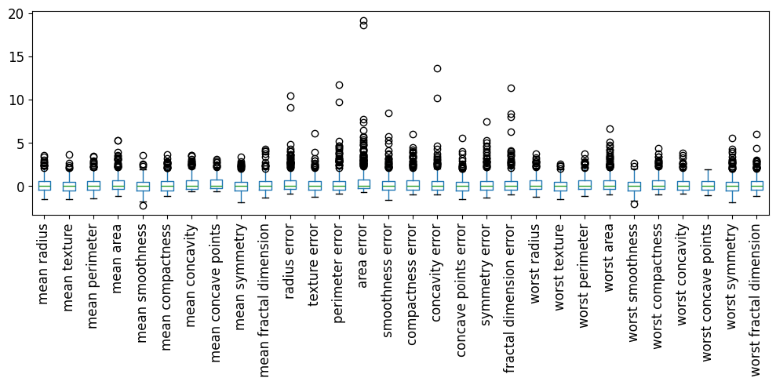

```python
# lets have a look at the boxplots of the scaled features
boxplots = x_train_robust_scaled.boxplot( # x is the data about the features and we are creating a boxplot for each feature
                     figsize= (10, 5), # this sets the (width, height) of the chart in inches so 10 inches by 5 inches
                     grid=False, # this removes the gridlines. Try setting this to True and rerunning it to see the gridlines
                     rot=90, # this rotates the x axis labels by 90 degrees so you can read them
                     fontsize=12 # this changes the font size to size 12
                     );

plt.tight_layout() # Adjust the padding between and around subplots by default value of 1.08. The padding is equal to 1.08 multiplied by the font size.
plt.show() # this forces the last plot to show. Useful if you have multiple plots in one code cell.
```

## 2.6. Model training

There are many different algorithms you can use to create a baseline model. We are doing a binary classification so would need a model that could do classification. More information on choosing a suitable algorithm can be found here https://www.geeksforgeeks.org/choosing-a-suitable-machine-learning-algorithm/

Normally we would check to see if others had already tried to solve this problem or a similar problem so we don't duplicate work and we learn from others. We assumed there aren't any models that use this data for this task.

Arbitrarily, linear support vector classifier has been chosen as the algorithm. This uses straight (linear) lines or hyperplanes to separate the data into the two classes or labels.

For example, the hyperplane shown in the chart below separates Class 1 and Class 2. Points to the left of the hyperplane would be predicted as Class 2. Points to the right of the hyperplane would be predicted as Class 1.

[figure not shown]

Source: https://www.ibm.com/topics/support-vector-machine

There are different settings, or hyperparameters, for the algorithm that are set by us. For simplicity, we will use the sklearn defaults.

More information about this algorithm and its hyperparameters can be found through the links:

- https://www.robots.ox.ac.uk/~az/lectures/ml/lect2.pdf
- https://www.ibm.com/topics/support-vector-machine
- https://scikit-learn.org/stable/modules/generated/sklearn.svm.LinearSVC.html
- https://www.analyticsvidhya.com/blog/2021/04/insight-into-svm-support-vector-machine-along-with-code/
- https://link.springer.com/protocol/10.1007/978-1-60327-241-4_13 (if you are able to gain access)

```python
# the model is only trained from the scaled train set
# we use the chosen random state to make sure that our results are replicatable
# we only need one line to train the model!
linear_svc_model = LinearSVC(random_state=chosen_random_state).fit(x_train_robust_scaled, y_train)
```

# 3. Model evaluation

We use the trained model and the test set to check how well the model performs on "unseen" data.

We need to quanitify "how well" the model performs. As we are doing supervised binary classification, we can use evaluation metrics such as accuracy, sensitivity, recall, specificity, precision and F-score. The most suitable evaluation metrics we choose depends on the specific problem we are looking to solve with the model and what our data looks like.

The evalution metrics mentioned can be calculated from what is called a confusion matrix. More information on how to calculate evaluation metrics from the confusion matrix can be found here https://www.nature.com/articles/s41598-024-56706-x

For example, in the confusion matrix below, there were 25 items (12 + 10 + 2 + 1) that were predicted.

- From the 25 that were predicted, the model got 22 correct (12 + 10).
- Out of 13 items (12 + 1) with actual label 0, 12 items (top left) were correctly predicted and 1 item (top right) was incorrectly predicted.
- Out of 12 items (2 + 10) with actual label 1, 10 items (bottom right) were correctly predicted and 2 items (bottom left) were incorrectly predicted.

[figure not shown]

Source: https://scikit-learn.org/stable/modules/generated/sklearn.metrics.ConfusionMatrixDisplay.html#sklearn.metrics.ConfusionMatrixDisplay.from_estimator

An example of how the confusion matrix can be used to calculate evaluation metrics can be seen below:

[figure not shown]

Source: https://www.kdnuggets.com/2022/11/confusion-matrix-precision-recall-explained.html

More information about confusion matrices can be found here https://www.analyticsvidhya.com/articles/confusion-matrix-in-machine-learning/

At this stage, these evaluation metrics may not tell you the full story of what the model is doing. You may want to do more analysis and check if the model is biased. For example, are there groups of people who the model performs worse for? More information about types of bias can be found here https://developers.google.com/machine-learning/crash-course/fairness/types-of-bias

```python
# these are the actual classifications
print("actual/true labels:")
y_test.values
```

```
actual/true labels:
```

```
array([1, 1, 0, 1, 0, 1, 1, 1, 0, 1, 1, 1, 1, 1, 1, 1, 1, 1, 0, 1, 1, 1,
       1, 0, 0, 1, 0, 1, 1, 0, 0, 1, 1, 1, 0, 1, 1, 1, 1, 1, 0, 1, 1, 1,
       1, 0, 1, 1, 0, 0, 1, 0, 0, 1, 0, 0, 0, 0, 0, 0, 0, 1, 1, 0, 1, 0,
       0, 0, 1, 1, 1, 1, 0, 0, 1, 1, 1, 1, 1, 1, 0, 1, 1, 1, 1, 0, 1, 0,
       1, 1, 1, 1, 1, 0, 1, 1, 0, 1, 1, 0, 1, 0, 0, 1, 0, 0, 1, 1, 1, 1,
       1, 0, 1, 0])
```

We need to scale the test data with the same formula/algorithm used to scale the train data

```python
x_test_robust_scaled = robust_scaler.transform(x_test)
```

```python
# using the trained model AND the test set, these show the predictions for the test set
print("predicted labels:")
pred_y_test = linear_svc_model.predict(x_test_robust_scaled)
pred_y_test
```

```
predicted labels:
```

```
array([1, 1, 0, 1, 0, 1, 1, 1, 0, 1, 0, 1, 1, 1, 1, 1, 1, 1, 0, 1, 1, 1,
       1, 0, 0, 1, 0, 1, 1, 0, 0, 1, 1, 1, 0, 1, 1, 1, 1, 1, 0, 1, 1, 1,
       1, 0, 1, 1, 0, 0, 1, 0, 0, 1, 0, 0, 0, 0, 0, 0, 0, 1, 1, 0, 1, 0,
       0, 0, 1, 1, 1, 1, 0, 0, 1, 1, 1, 1, 1, 1, 0, 1, 1, 1, 1, 0, 1, 0,
       1, 1, 1, 0, 1, 0, 1, 1, 0, 1, 1, 0, 1, 0, 0, 1, 0, 0, 1, 1, 1, 1,
       1, 0, 1, 0])
```

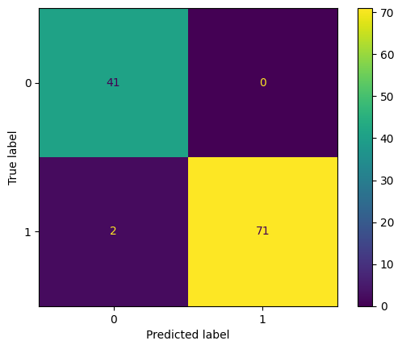

```python
# this is a chart of the confusion matrix
ConfusionMatrixDisplay.from_estimator(linear_svc_model, x_test_robust_scaled, y_test)
plt.show()
```

```
percentage of total count:
e.g. 0.36 represents 36 percent
```

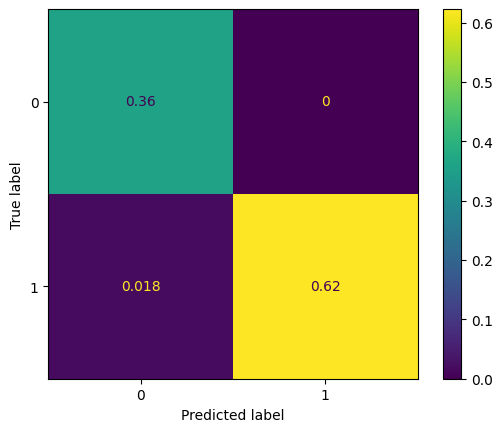

```python
# this is a chart of the confusion matrix but displayed as a percentage of the total number of items
print("""percentage of total count:
e.g. 0.36 represents 36 percent""")

ConfusionMatrixDisplay.from_estimator(linear_svc_model, x_test_robust_scaled, y_test, normalize="all")
plt.show()
```

# 4. Model explanation

As well as explaining mathematically how the model works, we also want to explain how the model uses the features to predict labels to provide an explanation to colleagues.

> Coefficients in Linear SVM:

> In a linear SVM, each feature is assigned a coefficient that represents its importance in the decision-making process. The coefficients are the weights assigned to the features, and the magnitude of these coefficients indicates the influence of each feature on the classification decision.

Source: https://www.geeksforgeeks.org/determining-feature-importance-in-svm-classifiers-with-scikit-learn/

A bar chart visualisation and a table of the coefficients will be shown.

In the event that we have a blank or null row or all of the values in a row are zero, then we take the intercept value as the final value to consider in the algorithm.

- If this value is >=0 then the predicted label is 1.
- If this value is <0 then the predicted label is 0.

Remember, the targets we are using are 0 and 1 which represents whether the tumour associated with the image is cancerous (=0) or non-cancerous (=1).

```python
#this shows the intercept of the model
print(f"""intercept: {linear_svc_model.intercept_}
      """)

#if the intercept is <0 then predict 0, otherwise predict 1
print("In the event that we have a blank or null row or all of the values in a row are zero:")
print("predict 0, cancerous") if linear_svc_model.intercept_<0 else print("predict 1, non-cancerous")
```

```
intercept: [1.19507428]

In the event that we have a blank or null row or all of the values in a row are zero:
predict 1, non-cancerous
```

```python
# this shows the coefficients of the model
print(f"""coefficients:
{linear_svc_model.coef_}
""")

# this shows the respective feature name for each coefficient
print(f"""respective feature names:
{x.columns}""")
```

```
coefficients:
[[ 0.31848008  0.00486253  0.24101267  0.27977807 -0.12776575  0.82747416
  -1.17767825 -0.8065777   0.1663606   0.12330525 -0.55845804  0.18688769
   0.1412473  -0.95481969 -0.18396256 -0.17570195  0.33310822 -0.48205819
   0.25377179  0.78658481 -0.59624766 -0.9437898  -0.62741665 -0.81438723
  -0.03862538  0.20201178 -0.40773594 -0.2423299  -0.51089546 -0.57919335]]

respective feature names:
Index(['mean radius', 'mean texture', 'mean perimeter', 'mean area',
       'mean smoothness', 'mean compactness', 'mean concavity',
       'mean concave points', 'mean symmetry', 'mean fractal dimension',
       'radius error', 'texture error', 'perimeter error', 'area error',
       'smoothness error', 'compactness error', 'concavity error',
       'concave points error', 'symmetry error', 'fractal dimension error',
       'worst radius', 'worst texture', 'worst perimeter', 'worst area',
       'worst smoothness', 'worst compactness', 'worst concavity',
       'worst concave points', 'worst symmetry', 'worst fractal dimension'],
      dtype='object')
```

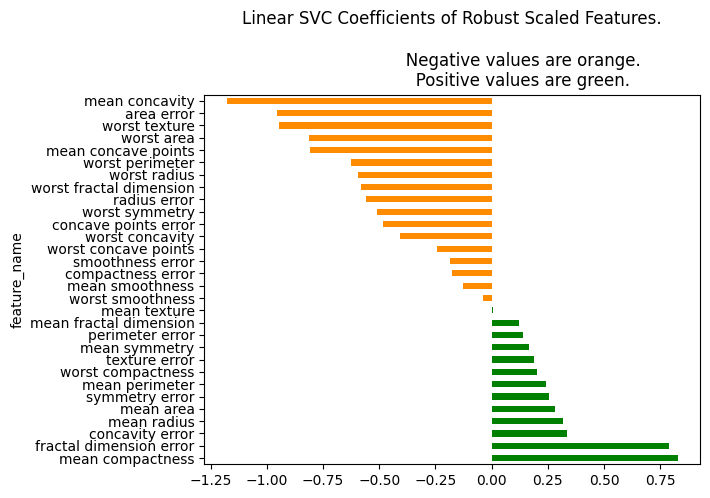

```python
# to create a bar chart of the coefficients, we need to restructure the data
# we want a column for "feature_name" and a column for "coefficient"
feat_importances = pd.DataFrame(columns=["feature_name", "coefficient"])

# we want to fill the feature_name column with the feature names
feat_importances["feature_name"] = x.columns

# we want to fill the coefficient column with the model coefficients
feat_importances["coefficient"] = linear_svc_model.coef_[0]

# we want to sort the data from low to high so the bar chart is easier to read
feat_importances = feat_importances.sort_values(by="coefficient", ascending=False)

# this plots the bar chart
feat_importances.plot.barh( # we want to plot a horizontal bar chart
                           x='feature_name', # we want a bar for each feature_name
                           y='coefficient', # the values of the bar will be the coefficient
                           color=(feat_importances.loc[:,'coefficient']>=0).map({True:'green', False:'darkorange'}), # bar colour. green if coefficient is >=0 and orange if <0
                           legend=False, #remove legend
                           title="""Linear SVC Coefficients of Robust Scaled Features.

                           Negative values are orange.
                           Positive values are green.""") #this is the title of the chart
# this shows the chart
plt.show()
```

```python
feat_importances
```

|  | feature_name | coefficient |
| --- | --- | --- |
| 5 | mean compactness | 0.827474 |
| 19 | fractal dimension error | 0.786585 |
| 16 | concavity error | 0.333108 |
| 0 | mean radius | 0.318480 |
| 3 | mean area | 0.279778 |
| 18 | symmetry error | 0.253772 |
| 2 | mean perimeter | 0.241013 |
| 25 | worst compactness | 0.202012 |
| 11 | texture error | 0.186888 |
| 8 | mean symmetry | 0.166361 |
| 12 | perimeter error | 0.141247 |
| 9 | mean fractal dimension | 0.123305 |
| 1 | mean texture | 0.004863 |
| 24 | worst smoothness | -0.038625 |
| 4 | mean smoothness | -0.127766 |
| 15 | compactness error | -0.175702 |
| 14 | smoothness error | -0.183963 |
| 27 | worst concave points | -0.242330 |
| 26 | worst concavity | -0.407736 |
| 17 | concave points error | -0.482058 |
| 28 | worst symmetry | -0.510895 |
| 10 | radius error | -0.558458 |
| 29 | worst fractal dimension | -0.579193 |
| 20 | worst radius | -0.596248 |
| 22 | worst perimeter | -0.627417 |
| 7 | mean concave points | -0.806578 |
| 23 | worst area | -0.814387 |
| 21 | worst texture | -0.943790 |
| 13 | area error | -0.954820 |
| 6 | mean concavity | -1.177678 |

# 5. Improve the model

Unless the model meets the needs of your colleague and can be used in a live system, the model may need to be improved or the project abandoned.

# !NOTE OF CAUTION!

- This notebook is purely for learning purposes and has little relevance to real world solutions as users, customers and stakeholders were not involved.
- In addition, there are many other methodological and wider considerations to be taken into account when building and using AI models that have not been considered here.

Examples of other considerations include:

> - Governance
> - Privacy
> - Security
> - Safety
> - Replication of outcomes
> - AI performance
> - Avoidance of bias
> - Accountability
> - Human rights & social responsibility
> - Suppliers responsibilities

Source: https://www.bcs.org/articles-opinion-and-research/10-critical-considerations-when-developing-an-ai-system/

> - Problem definition
> - Data quality
> - Model selection
> - Integration with existing systems
> - Ethical considerations

Source: https://www.turing.com/blog/ai-implementation-strategy-tips

> - MLOps

Source: https://www.databricks.com/glossary/mlops

Advice on how to plan and prepare for an AI project can be found here https://www.gov.uk/guidance/assessing-if-artificial-intelligence-is-the-right-solution and here https://www.gov.uk/guidance/planning-and-preparing-for-artificial-intelligence-implementation